# Homework #6 - Answer Key

Mark Scheuerell

Here are the answers for the homework problems from the sixth week of class on the Dynamic Linear Models (DLMs) material. Begin by getting the data

```r
# get S-R data; cols are:
# 1: brood yr (brood.yr)
# 2: number of spawners (Sp)
# 3: number of recruits (Rec)
# 4: PDO during first summer at sea (PDO.t2)
# 5: PDO during first winter at sea (PDO.t3)
load("KvichakSockeye.RData")
```

### Question 1

> Begin by fitting a reduced form of Equation 15 that includes only a time-varying level ($\alpha_t$) and observation error ($v_t$). Although you will be modeling productivity as completely independent of their parents, it will provde some insights as to the overall temporal pattern in recruitment. Plot the ts of $\alpha_t$ and note the AICc for this model.

The first thing we need is to compute the response variable: ln(R/S).

```r
# Time series of ln(R/S)
lnRS = log(SRdata$Rec/SRdata$Sp)
dat = matrix(lnRS, nrow=1)
# number of years of data--we'll need this later
TT = length(lnRS)
```

Now we can set up the DLM as a level-only model (i.e., a random walk with observation error) and fit it with MARSS.

```r
library(MARSS)
# MARSS model defn
# for process eqn
BB = matrix(1)
UU = matrix(0)
QQ = matrix("q")
# for observation eqn
ZZ = matrix(1)
AA = matrix(0)
RR = matrix("r")
# only need starting values for regr parameters
inits.list = list(x0=matrix(1))
# list of model matrices & vectors
mod.list = list(B=BB, U=UU, Q=QQ, Z=ZZ, A=AA, R=RR, tinitx=0)
# fit DLM
Q1 = MARSS(dat, inits=inits.list, model=mod.list)
```

```
## Success! abstol and log-log tests passed at 22 iterations.
## Alert: conv.test.slope.tol is 0.5.
## Test with smaller values (<0.1) to ensure convergence.
##
## MARSS fit is
## Estimation method: kem
## Convergence test: conv.test.slope.tol = 0.5, abstol = 0.001
## Estimation converged in 22 iterations.
## Log-likelihood: -48.67502
## AIC: 103.35   AICc: 104.0559
##
##       Estimate
## R.r      0.271
## Q.q      0.318
## x0.x0    0.953
##
## Standard errors have not been calculated.
## Use MARSSparamCIs to compute CIs and bias estimates.
```

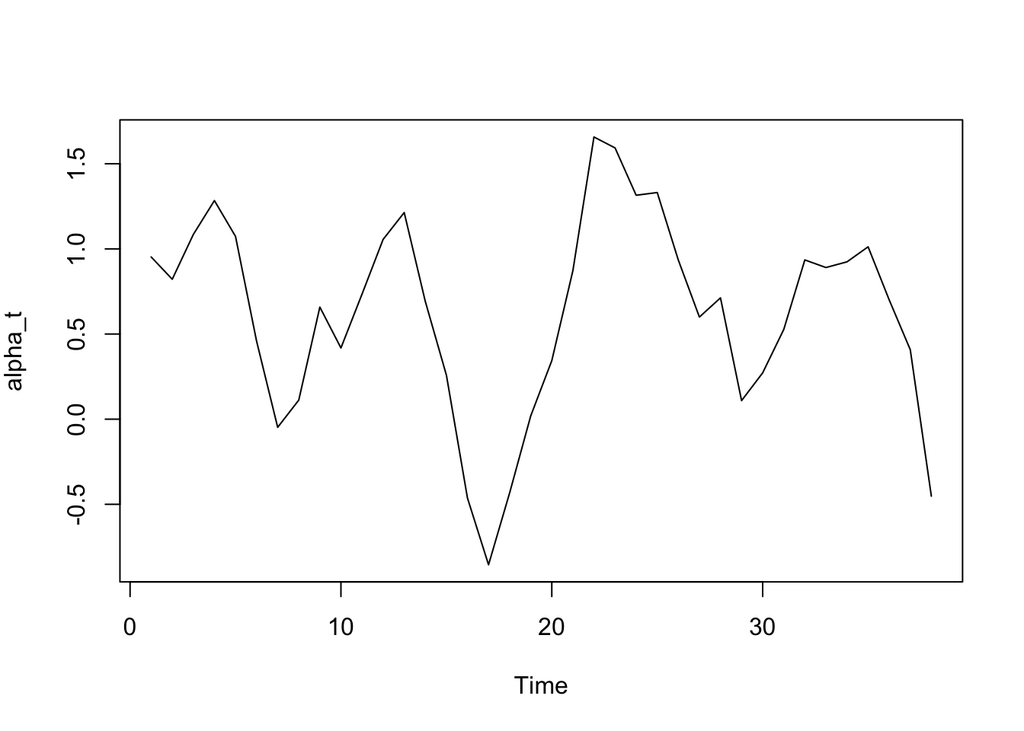

```r
# plot the time-varying level
plot.ts(t(Q1$states), ylab=expression(alpha_t))
```

```r
# get AIC
Q1$AIC
```

```
## [1] 103.35
```

And finally examine some diagnostic plots:

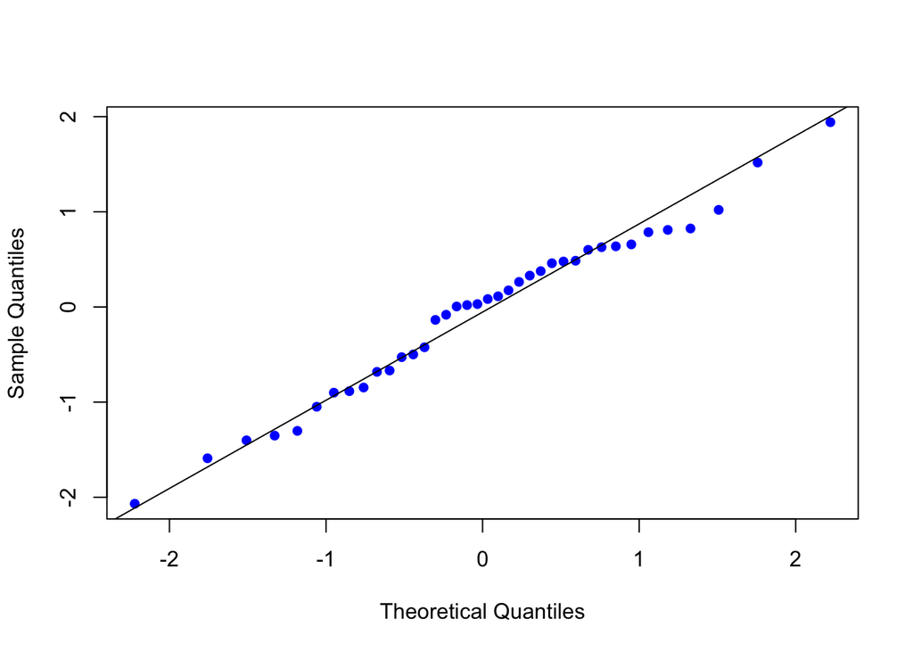

```r
# get list of Kalman filter output
kf.out = MARSSkfss(Q1)
# forecast errors
innov = kf.out$Innov
# Q-Q plot of forecast errors
qqnorm(t(innov), main="", pch=16, col="blue")
# add y=x line for easier interpretation
qqline(t(innov))
```

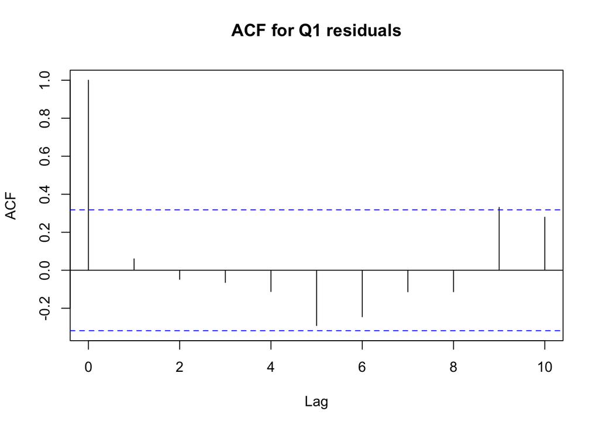

```r
# plot ACF of innovations
acf(t(innov), lag.max=10, main="ACF for Q1 residuals")
```

### Question 2

> Fit the full model specified by Equation 15. For this model, obtain the time series of $\alpha_t$, which is an estimate of the stock productivity in the absence of density-dependent effects. How do these estimates of productivity compare to those from the previous question? Plot the ts of $\alpha_t$ and note the AICc for this model. (*Hint*: If you don’t want a parameter to vary with time, what does that say about its process variance?.)

Now we need to fit a DLM with a time-varying level (intercept), but time-invariant slope. Begin by obtaining the time series of spawners to use as the covariate.

```r
Sp = matrix(SRdata$Sp, nrow=1)
```

Now set up the MARSS model structure so $\alpha$ varies with time, but not $\beta$, which means $q=0$ for $\beta$ .

```r
# number of regr coefs
m = 2
# MARSS model defn
# for process eqn
B = diag(m)                   # 2x2; Identity
U = matrix(0,nrow=m,ncol=1)   # 2x1; both elements = 0
Q = matrix(list(0),m,m)       # 2x2; all 0 for now
Q[1,1] = "q"                  # 2x2; diag = (q1,q2)
# for observation eqn
Z = array(NA, c(1,m,TT))   # NxMxT; empty for now
Z[1,1,] = rep(1,TT)        # Nx1; 1's for intercept
Z[1,2,] = Sp               # Nx1; regr variable
A = matrix(0)              # 1x1; scalar = 0
R = matrix("r")            # 1x1; scalar = r
# only need starting values for regr parameters
inits.list = list(x0=matrix(c(0, 0), nrow=m))
# list of model matrices & vectors
mod.list = list(B=B, U=U, Q=Q, Z=Z, A=A, R=R)
# fit DLM
Q2 = MARSS(dat, inits=inits.list, model=mod.list)
```

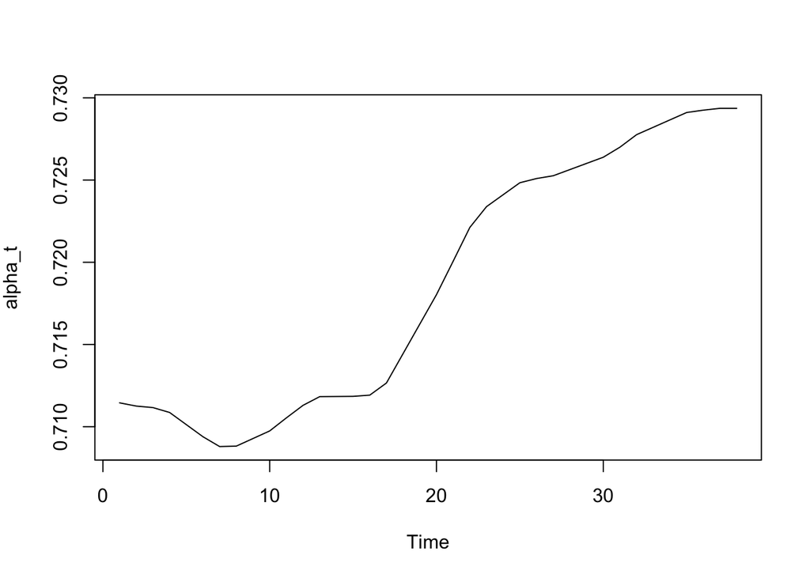

```r
# plot the time-varying level
plot.ts(Q2$states[1,], ylab=expression(alpha_t))
```

```r
# get AIC
Q2$AIC
```

```
## [1] 76.21261
```

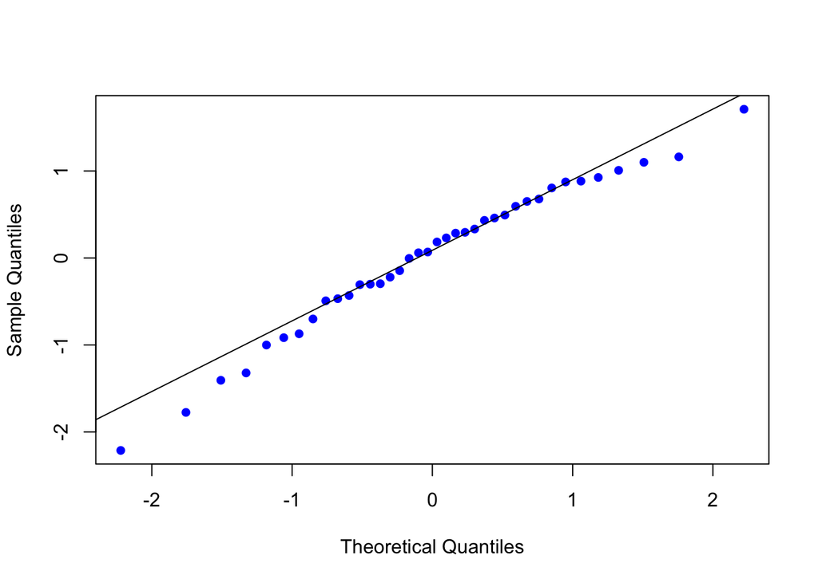

```r
# get list of Kalman filter output
kf.out = MARSSkfss(Q2)
# forecast errors
innov = kf.out$Innov
# Q-Q plot of forecast errors
qqnorm(t(innov), main="", pch=16, col="blue")
# add y=x line for easier interpretation
qqline(t(innov))
```

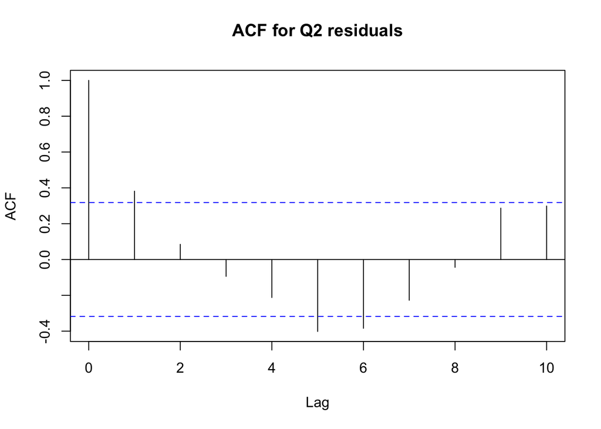

```r
# plot ACF of innovations
acf(t(innov), lag.max=10, main="ACF for Q2 residuals")
```

### Question 3

> Fit the model specified by Equation 16 with the summer PDO index as the covariate (). What is the mean level of productivity? Plot the ts of $\delta_t$ and note the AICc for this model. Also plot appropriate model diagnostics.

Now we need to fit a DLM so $\alpha$ and $\beta$ are time-invariant, but $\delta$ varies by year.

```r
# number of regr coefs
m = 3
# MARSS model defn
# for process eqn
B = diag(m) # 2x2; Identity
U = matrix(0,nrow=m,ncol=1)
Q = matrix(list(0),m,m)
# place delta last--it's the only one to time-vary
Q[3,3]=("q1")
# for observation eqn
Z = array(NA, c(1,m,TT)) # NxMxT; empty for now
Z[1,1,] = rep(1,TT)  # 1's for intercept
Z[1,2,] = SRdata[,2] # Sp regr variable
Z[1,3,] = SRdata[,4] # summer PDO regr variable
A = matrix(0) # 1x1; scalar = 0
R = matrix("r") # 1x1; scalar = r
# only need starting values for regr parameters
inits.list = list(x0=matrix(c(0,0,0), nrow=m))
# list of model matrices & vectors
mod.list = list(B=B, U=U, Q=Q, Z=Z, A=A, R=R)
# fit DLM
Q3 = MARSS(dat, inits=inits.list, model=mod.list)
```

```
## Warning! Reached maxit before parameters converged. Maxit was 500.
##  neither abstol nor log-log convergence tests were passed.
## Alert: Numerical warnings were generated. Print the $errors element of output to see the warnings.
##
## MARSS fit is
## Estimation method: kem
## Convergence test: conv.test.slope.tol = 0.5, abstol = 0.001
## WARNING: maxit reached at  500  iter before convergence.
##  Neither abstol nor log-log convergence test were passed.
##  The likelihood and params are not at the ML values.
##  Try setting control$maxit higher.
## Log-likelihood: -34.69718
## AIC: 79.39436   AICc: 81.26936
##
##        Estimate
## R.r    7.54e-01
## Q.q1   1.68e-04
## x0.X1  7.26e-01
## x0.X2 -2.03e-05
## x0.X3 -1.20e-01
##
## Standard errors have not been calculated.
## Use MARSSparamCIs to compute CIs and bias estimates.
##
## Convergence warnings
##  Warning: the  Q.q1  parameter value has not converged.
##  Warning: the  logLik  parameter value has not converged.
##  Type MARSSinfo("convergence") for more info on this warning.
##
## MARSSkem warnings. Type MARSSinfo() for help.
##  MARSSkem: The soln became unstable and logLik DROPPED.
##
## Use control$trace=1 to generate a more detailed error report.
```

```r
# mean productivity
mean(Q3$states[1,])
```

```
## [1] 0.726088
```

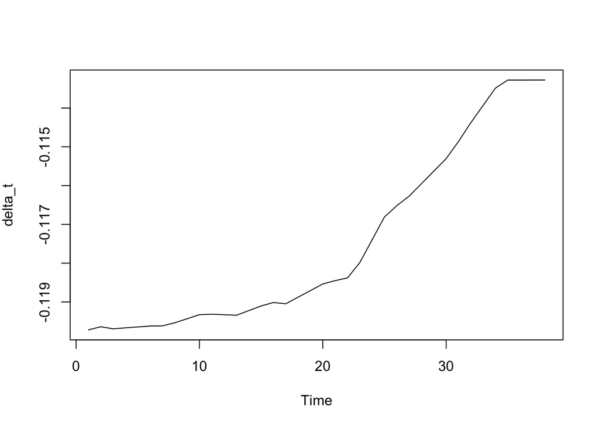

```r
# plot the time-varying effect of PDO
plot.ts(Q3$states[3,], ylab=expression(delta_t))
```

```r
# get AIC
Q3$AIC
```

```
## [1] 79.39436
```

It looks like the effect of PDO $(\delta_t)$ is increasing over time.

Here are some diagnostic plots:

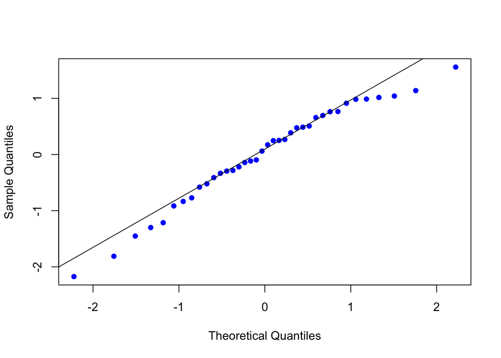

```r
# get list of Kalman filter output
kf.out = MARSSkfss(Q3)
# forecast errors
innov = kf.out$Innov
# Q-Q plot of forecast errors
qqnorm(t(innov), main="", pch=16, col="blue")
# add y=x line for easier interpretation
qqline(t(innov))
```

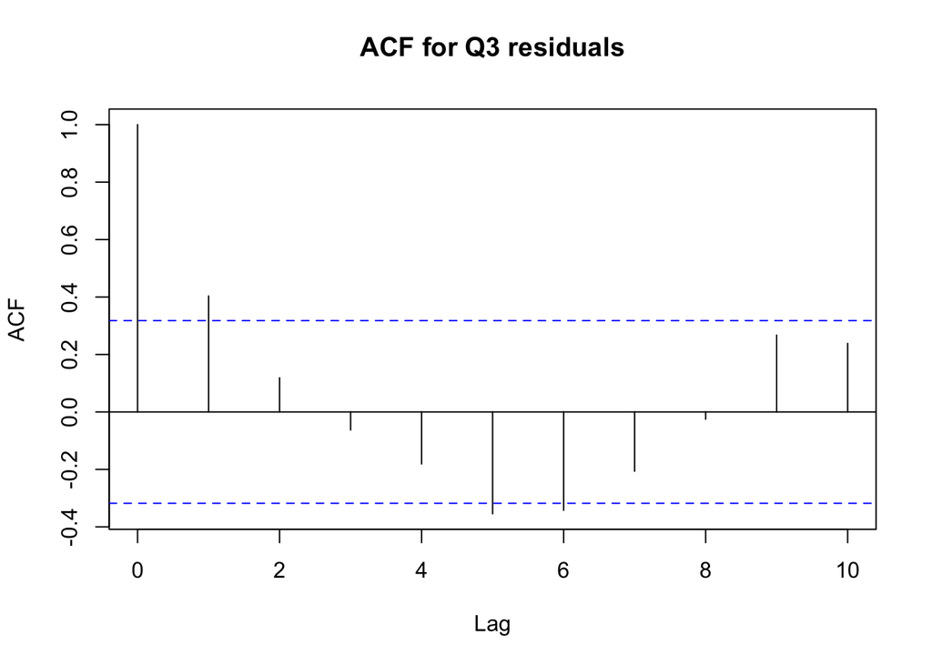

```r
# plot ACF of innovations
acf(t(innov), lag.max=10, main="ACF for Q3 residuals")
```

There is some indication that our model is not adequately accounting for autocorrelation in the residuals (i.e., signficant correlation at lag=1).

### Question 4

> Fit the model specified by Equation 16 with the winter PDO index as the covariate (). What is the mean level of productivity? Plot the ts of $\delta_t$ and note the AICc for this model. Also plot appropriate model diagnostics.

Again we need to fit a DLM so that $\alpha$ and $\beta$ are time-invariant, but $\delta$ varies by year.

```r
# number of regr coefs
m = 3
# MARSS model defn
# for process eqn
B = diag(m) # 2x2; Identity
U = matrix(0,nrow=m,ncol=1)
Q = matrix(list(0),m,m)
# place delta last--it's the only one to time-vary
Q[3,3]=("q1")
# for observation eqn
Z = array(NA, c(1,m,TT)) # NxMxT; empty for now
Z[1,1,] = rep(1,TT)  # 1's for intercept
Z[1,2,] = SRdata[,2] # Sp regr variable
Z[1,3,] = SRdata[,5] # winter PDO regr variable
A = matrix(0) # 1x1; scalar = 0
R = matrix("r") # 1x1; scalar = r
# only need starting values for regr parameters
inits.list = list(x0=matrix(c(0,0,0), nrow=m))
# list of model matrices & vectors
mod.list = list(B=B, U=U, Q=Q, Z=Z, A=A, R=R)
# fit DLM
Q4 = MARSS(dat, inits=inits.list, model=mod.list)
```

```
## Warning! Abstol convergence only. Maxit (=500) reached before log-log convergence.
## Alert: Numerical warnings were generated. Print the $errors element of output to see the warnings.
##
## MARSS fit is
## Estimation method: kem
## Convergence test: conv.test.slope.tol = 0.5, abstol = 0.001
## WARNING: Abstol convergence only no log-log convergence.
##  maxit (=500) reached before log-log convergence.
##  The likelihood and params might not be at the ML values.
##  Try setting control$maxit higher.
## Log-likelihood: -34.08729
## AIC: 78.17458   AICc: 80.04958
##
##        Estimate
## R.r    7.24e-01
## Q.q1   1.71e-04
## x0.X1  7.26e-01
## x0.X2 -1.83e-05
## x0.X3  1.12e-02
##
## Standard errors have not been calculated.
## Use MARSSparamCIs to compute CIs and bias estimates.
##
## Convergence warnings
##  Warning: the  Q.q1  parameter value has not converged.
##  Warning: the  x0.X3  parameter value has not converged.
##  Type MARSSinfo("convergence") for more info on this warning.
##
## MARSSkem warnings. Type MARSSinfo() for help.
##  MARSSkem: The soln became unstable and logLik DROPPED.
##
## Use control$trace=1 to generate a more detailed error report.
```

```r
# mean productivity
mean(Q4$states[1,])
```

```
## [1] 0.7262697
```

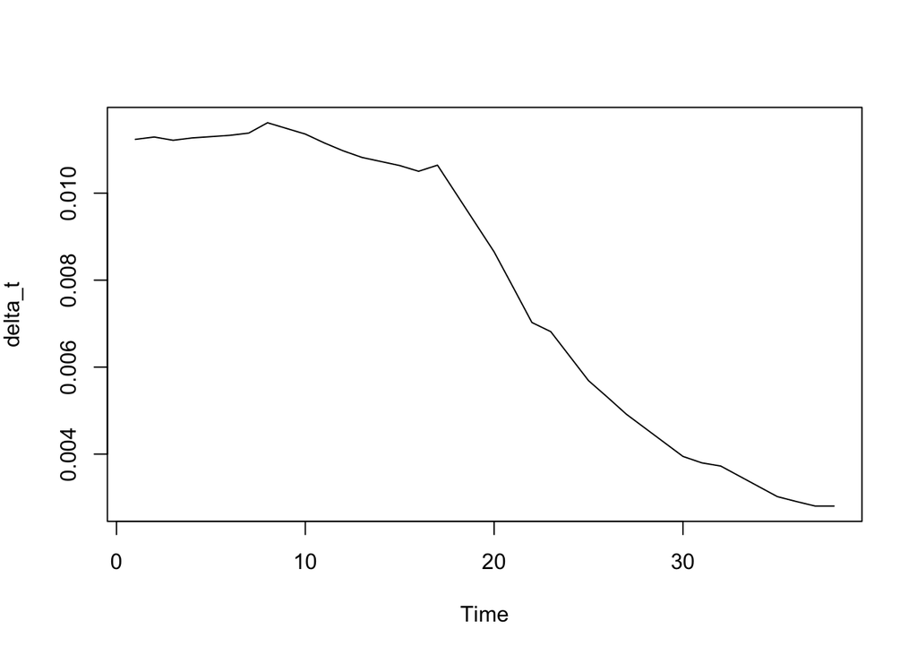

```r
# plot the time-varying effect of PDO
plot.ts(Q4$states[3,], ylab=expression(delta_t))
```

```r
# get AIC
Q4$AIC
```

```
## [1] 78.17458
```

It looks like the effect of PDO was initially flat over time, but then about half-way through the time series there is a decline in its effect.

Here are some diagnostic plots:

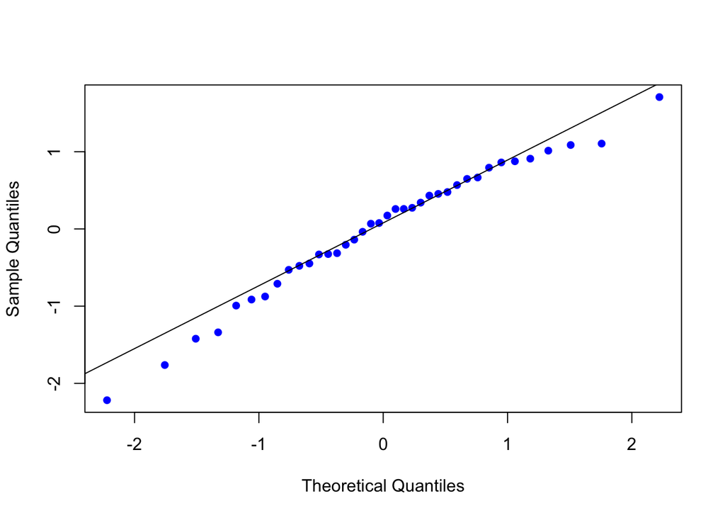

```r
# get list of Kalman filter output
kf.out = MARSSkfss(Q4)
# forecast errors
innov = kf.out$Innov
# Q-Q plot of forecast errors
qqnorm(t(innov), main="", pch=16, col="blue")
# add y=x line for easier interpretation
qqline(t(innov))
```

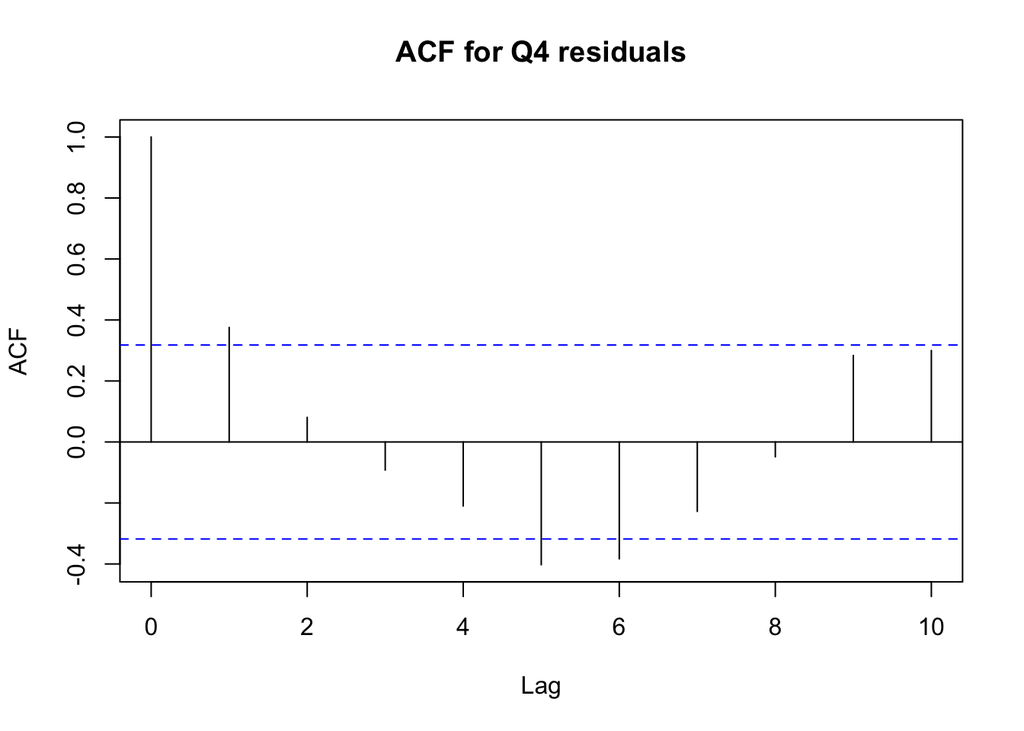

```r
# plot ACF of innovations
acf(t(innov), lag.max=10, main="ACF for Q4 residuals")
```

### Question 5

> Based on AICc, which of the models above is the most parsimonius? Is it well behaved ($i.e.$, are the model assumptions met)? Plot the model forecasts for the best model. Is this a good forecast model?

We’ll use AIC to evaluate the most parsimonius model.

```r
which.min(c(Q1$AIC,Q2$AIC,Q3$AIC,Q4$AIC))
```

```
## [1] 2
```

```r
# get list of Kalman filter output
kf.out = MARSSkfss(Q1)
# forecasts of regr parameters; 2xT matrix
eta = kf.out$xtt1
# predictor variable (1's only for the intercept)
Z = array(NA, c(1,1,TT))   # NxMxT; empty for now
Z[1,1,] = rep(1,TT)        # Nx1; 1's for intercept
# ts of E(forecasts)
fore.mean = vector()
for(t in 1:TT) {
  fore.mean[t] = Z[,,t] %*% eta[,t,drop=F]
}
# variance of regr parameters; 1x2xT array
Phi = kf.out$Vtt1
# obs variance; 1x1 matrix
R.est = coef(Q1, type="matrix")$R
# ts of Var(forecasts)
fore.var = vector()
for(t in 1:TT) {
  tZ = matrix(Z[,,t],1,1) # transpose of Z
  fore.var[t] = Z[,,t] %*% Phi[,,t] %*% tZ + R.est
}
```

And now we can plot them.

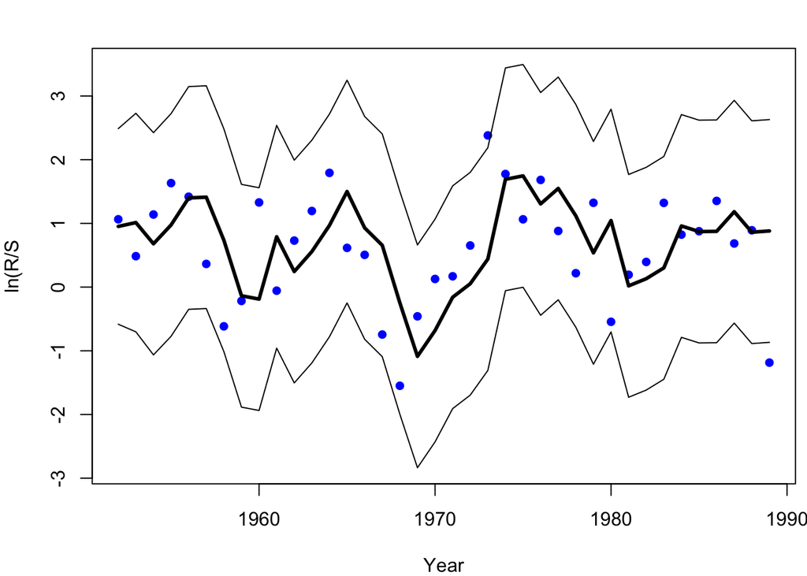

```r
fup = fore.mean+2*sqrt(fore.var)
flo = fore.mean-2*sqrt(fore.var)
par(mar=c(4,4,0.1,0), oma=c(0,0,2,0.5))
ylims=c(min(flo),max(fup))
plot(SRdata$brood.yr, t(dat), type="p", pch=16, ylim=ylims,
     col="blue", xlab="Year", ylab="ln(R/S") #, xaxt="n")
lines(SRdata$brood.yr, fore.mean, type="l", xaxt="n", ylab="", lwd=3)
lines(SRdata$brood.yr, fup)
lines(SRdata$brood.yr, flo)
```

Overall, the accuracy of the forecasts is a bit suspect as many observations are at 0.5+ log-units from the forecast. Although most of the observed ln(R/S) fell within the 95% forecast intervals, the intervals themselves are relatively large and span a large range of R/S.